# miniproj1_v1

# papers' topics in trend

```python
topics_df.index = preprocessed_df.columns
topics_df["kmeans_label"] = papers_label_l
topics_df["year"] = [each.split("_")[0] for each in topics_df.index]
topics_df
```

|  | 0 | 1 | 2 | 3 | 4 | 5 | 6 | 7 | 8 | 9 | kmeans_label | year |
| --- | --- | --- | --- | --- | --- | --- | --- | --- | --- | --- | --- | --- |
| 1987_1 | 0.184561 | 0.000127 | 0.000127 | 0.171693 | 0.118584 | 0.046351 | 0.008858 | 0.000127 | 0.114573 | 0.354999 | 1 | 1987 |
| 1987_2 | 0.000046 | 0.000046 | 0.024523 | 0.054455 | 0.014647 | 0.000046 | 0.000046 | 0.000046 | 0.232756 | 0.673388 | 1 | 1987 |
| 1987_3 | 0.000085 | 0.000085 | 0.000085 | 0.000085 | 0.000085 | 0.252465 | 0.000085 | 0.038528 | 0.000085 | 0.708410 | 1 | 1987 |
| 1987_4 | 0.000063 | 0.026243 | 0.080380 | 0.000063 | 0.000063 | 0.029452 | 0.000063 | 0.025753 | 0.225012 | 0.612906 | 1 | 1987 |
| 1987_5 | 0.220577 | 0.015074 | 0.000044 | 0.002619 | 0.000044 | 0.091677 | 0.000044 | 0.000044 | 0.045857 | 0.624019 | 1 | 1987 |
| ... | ... | ... | ... | ... | ... | ... | ... | ... | ... | ... | ... | ... |
| 2015_399 | 0.020617 | 0.000045 | 0.008918 | 0.028291 | 0.003500 | 0.712540 | 0.000045 | 0.000045 | 0.000045 | 0.225953 | 0 | 2015 |
| 2015_400 | 0.000065 | 0.000065 | 0.000065 | 0.895912 | 0.086683 | 0.016949 | 0.000065 | 0.000065 | 0.000065 | 0.000065 | 8 | 2015 |
| 2015_401 | 0.093734 | 0.000047 | 0.000047 | 0.814402 | 0.024980 | 0.066603 | 0.000047 | 0.000047 | 0.000047 | 0.000047 | 8 | 2015 |
| 2015_402 | 0.005591 | 0.000048 | 0.000048 | 0.137074 | 0.023992 | 0.833056 | 0.000048 | 0.000048 | 0.000048 | 0.000048 | 0 | 2015 |
| 2015_403 | 0.000049 | 0.000049 | 0.129501 | 0.026874 | 0.818119 | 0.025213 | 0.000049 | 0.000049 | 0.000049 | 0.000049 | 2 | 2015 |

5811 rows × 12 columns

```python
pivot = pd.DataFrame(topics_df.groupby(["year", "kmeans_label"]).count()[0]).unstack()[0].fillna(0)


pivot
```

| kmeans_label year | 0 | 1 | 2 | 3 | 4 | 5 | 6 | 7 | 8 | 9 |
| --- | --- | --- | --- | --- | --- | --- | --- | --- | --- | --- |
| 1987 | 1.0 | 58.0 | 0.0 | 4.0 | 0.0 | 2.0 | 5.0 | 19.0 | 1.0 | 0.0 |
| 1988 | 1.0 | 56.0 | 0.0 | 5.0 | 2.0 | 1.0 | 7.0 | 21.0 | 0.0 | 2.0 |
| 1989 | 1.0 | 59.0 | 1.0 | 5.0 | 2.0 | 2.0 | 6.0 | 19.0 | 1.0 | 5.0 |
| 1990 | 0.0 | 74.0 | 8.0 | 8.0 | 2.0 | 6.0 | 10.0 | 16.0 | 4.0 | 15.0 |
| 1991 | 2.0 | 56.0 | 12.0 | 11.0 | 7.0 | 4.0 | 13.0 | 25.0 | 3.0 | 11.0 |
| 1992 | 2.0 | 55.0 | 9.0 | 10.0 | 3.0 | 6.0 | 12.0 | 16.0 | 5.0 | 9.0 |
| 1993 | 4.0 | 54.0 | 15.0 | 16.0 | 4.0 | 5.0 | 7.0 | 19.0 | 8.0 | 12.0 |
| 1994 | 4.0 | 51.0 | 20.0 | 12.0 | 2.0 | 5.0 | 11.0 | 15.0 | 9.0 | 11.0 |
| 1995 | 2.0 | 45.0 | 24.0 | 10.0 | 11.0 | 2.0 | 14.0 | 20.0 | 13.0 | 11.0 |
| 1996 | 10.0 | 26.0 | 39.0 | 5.0 | 9.0 | 4.0 | 22.0 | 12.0 | 12.0 | 13.0 |
| 1997 | 7.0 | 21.0 | 27.0 | 14.0 | 10.0 | 9.0 | 18.0 | 20.0 | 13.0 | 12.0 |
| 1998 | 7.0 | 15.0 | 37.0 | 17.0 | 10.0 | 6.0 | 16.0 | 17.0 | 18.0 | 8.0 |
| 1999 | 13.0 | 17.0 | 40.0 | 10.0 | 11.0 | 5.0 | 8.0 | 25.0 | 13.0 | 8.0 |
| 2000 | 15.0 | 11.0 | 35.0 | 8.0 | 10.0 | 8.0 | 11.0 | 10.0 | 11.0 | 17.0 |
| 2001 | 5.0 | 5.0 | 21.0 | 7.0 | 9.0 | 13.0 | 5.0 | 5.0 | 17.0 | 15.0 |
| 2002 | 21.0 | 3.0 | 30.0 | 17.0 | 23.0 | 12.0 | 10.0 | 18.0 | 1.0 | 17.0 |
| 2003 | 26.0 | 5.0 | 29.0 | 20.0 | 26.0 | 14.0 | 6.0 | 24.0 | 24.0 | 23.0 |
| 2004 | 37.0 | 7.0 | 26.0 | 22.0 | 28.0 | 14.0 | 7.0 | 20.0 | 18.0 | 27.0 |
| 2005 | 35.0 | 4.0 | 31.0 | 24.0 | 28.0 | 17.0 | 13.0 | 26.0 | 12.0 | 17.0 |
| 2006 | 38.0 | 4.0 | 33.0 | 29.0 | 23.0 | 20.0 | 7.0 | 18.0 | 12.0 | 20.0 |
| 2007 | 39.0 | 1.0 | 34.0 | 13.0 | 37.0 | 21.0 | 7.0 | 16.0 | 23.0 | 26.0 |
| 2008 | 55.0 | 3.0 | 38.0 | 13.0 | 37.0 | 32.0 | 6.0 | 17.0 | 20.0 | 29.0 |
| 2009 | 60.0 | 0.0 | 28.0 | 22.0 | 39.0 | 30.0 | 11.0 | 11.0 | 24.0 | 37.0 |
| 2010 | 59.0 | 4.0 | 30.0 | 27.0 | 55.0 | 22.0 | 16.0 | 16.0 | 30.0 | 33.0 |
| 2011 | 64.0 | 2.0 | 40.0 | 30.0 | 50.0 | 28.0 | 6.0 | 14.0 | 40.0 | 31.0 |
| 2012 | 86.0 | 6.0 | 63.0 | 27.0 | 56.0 | 31.0 | 10.0 | 13.0 | 34.0 | 41.0 |
| 2013 | 106.0 | 9.0 | 54.0 | 16.0 | 57.0 | 20.0 | 9.0 | 12.0 | 46.0 | 31.0 |
| 2014 | 111.0 | 9.0 | 54.0 | 32.0 | 74.0 | 19.0 | 4.0 | 18.0 | 38.0 | 52.0 |
| 2015 | 115.0 | 16.0 | 68.0 | 25.0 | 77.0 | 20.0 | 6.0 | 5.0 | 43.0 | 28.0 |

```python
pivot_scaled = (pivot.transpose() / pivot.sum(axis=1)).transpose()
pivot_scaled
```

| kmeans_label year | 0 | 1 | 2 | 3 | 4 | 5 | 6 | 7 | 8 | 9 |
| --- | --- | --- | --- | --- | --- | --- | --- | --- | --- | --- |
| 1987 | 0.011111 | 0.644444 | 0.000000 | 0.044444 | 0.000000 | 0.022222 | 0.055556 | 0.211111 | 0.011111 | 0.000000 |
| 1988 | 0.010526 | 0.589474 | 0.000000 | 0.052632 | 0.021053 | 0.010526 | 0.073684 | 0.221053 | 0.000000 | 0.021053 |
| 1989 | 0.009901 | 0.584158 | 0.009901 | 0.049505 | 0.019802 | 0.019802 | 0.059406 | 0.188119 | 0.009901 | 0.049505 |
| 1990 | 0.000000 | 0.517483 | 0.055944 | 0.055944 | 0.013986 | 0.041958 | 0.069930 | 0.111888 | 0.027972 | 0.104895 |
| 1991 | 0.013889 | 0.388889 | 0.083333 | 0.076389 | 0.048611 | 0.027778 | 0.090278 | 0.173611 | 0.020833 | 0.076389 |
| 1992 | 0.015748 | 0.433071 | 0.070866 | 0.078740 | 0.023622 | 0.047244 | 0.094488 | 0.125984 | 0.039370 | 0.070866 |
| 1993 | 0.027778 | 0.375000 | 0.104167 | 0.111111 | 0.027778 | 0.034722 | 0.048611 | 0.131944 | 0.055556 | 0.083333 |
| 1994 | 0.028571 | 0.364286 | 0.142857 | 0.085714 | 0.014286 | 0.035714 | 0.078571 | 0.107143 | 0.064286 | 0.078571 |
| 1995 | 0.013158 | 0.296053 | 0.157895 | 0.065789 | 0.072368 | 0.013158 | 0.092105 | 0.131579 | 0.085526 | 0.072368 |
| 1996 | 0.065789 | 0.171053 | 0.256579 | 0.032895 | 0.059211 | 0.026316 | 0.144737 | 0.078947 | 0.078947 | 0.085526 |
| 1997 | 0.046358 | 0.139073 | 0.178808 | 0.092715 | 0.066225 | 0.059603 | 0.119205 | 0.132450 | 0.086093 | 0.079470 |
| 1998 | 0.046358 | 0.099338 | 0.245033 | 0.112583 | 0.066225 | 0.039735 | 0.105960 | 0.112583 | 0.119205 | 0.052980 |
| 1999 | 0.086667 | 0.113333 | 0.266667 | 0.066667 | 0.073333 | 0.033333 | 0.053333 | 0.166667 | 0.086667 | 0.053333 |
| 2000 | 0.110294 | 0.080882 | 0.257353 | 0.058824 | 0.073529 | 0.058824 | 0.080882 | 0.073529 | 0.080882 | 0.125000 |
| 2001 | 0.049020 | 0.049020 | 0.205882 | 0.068627 | 0.088235 | 0.127451 | 0.049020 | 0.049020 | 0.166667 | 0.147059 |
| 2002 | 0.138158 | 0.019737 | 0.197368 | 0.111842 | 0.151316 | 0.078947 | 0.065789 | 0.118421 | 0.006579 | 0.111842 |
| 2003 | 0.131980 | 0.025381 | 0.147208 | 0.101523 | 0.131980 | 0.071066 | 0.030457 | 0.121827 | 0.121827 | 0.116751 |
| 2004 | 0.179612 | 0.033981 | 0.126214 | 0.106796 | 0.135922 | 0.067961 | 0.033981 | 0.097087 | 0.087379 | 0.131068 |
| 2005 | 0.169082 | 0.019324 | 0.149758 | 0.115942 | 0.135266 | 0.082126 | 0.062802 | 0.125604 | 0.057971 | 0.082126 |
| 2006 | 0.186275 | 0.019608 | 0.161765 | 0.142157 | 0.112745 | 0.098039 | 0.034314 | 0.088235 | 0.058824 | 0.098039 |
| 2007 | 0.179724 | 0.004608 | 0.156682 | 0.059908 | 0.170507 | 0.096774 | 0.032258 | 0.073733 | 0.105991 | 0.119816 |
| 2008 | 0.220000 | 0.012000 | 0.152000 | 0.052000 | 0.148000 | 0.128000 | 0.024000 | 0.068000 | 0.080000 | 0.116000 |
| 2009 | 0.229008 | 0.000000 | 0.106870 | 0.083969 | 0.148855 | 0.114504 | 0.041985 | 0.041985 | 0.091603 | 0.141221 |
| 2010 | 0.202055 | 0.013699 | 0.102740 | 0.092466 | 0.188356 | 0.075342 | 0.054795 | 0.054795 | 0.102740 | 0.113014 |
| 2011 | 0.209836 | 0.006557 | 0.131148 | 0.098361 | 0.163934 | 0.091803 | 0.019672 | 0.045902 | 0.131148 | 0.101639 |
| 2012 | 0.234332 | 0.016349 | 0.171662 | 0.073569 | 0.152589 | 0.084469 | 0.027248 | 0.035422 | 0.092643 | 0.111717 |
| 2013 | 0.294444 | 0.025000 | 0.150000 | 0.044444 | 0.158333 | 0.055556 | 0.025000 | 0.033333 | 0.127778 | 0.086111 |
| 2014 | 0.270073 | 0.021898 | 0.131387 | 0.077859 | 0.180049 | 0.046229 | 0.009732 | 0.043796 | 0.092457 | 0.126521 |
| 2015 | 0.285360 | 0.039702 | 0.168734 | 0.062035 | 0.191067 | 0.049628 | 0.014888 | 0.012407 | 0.106700 | 0.069479 |

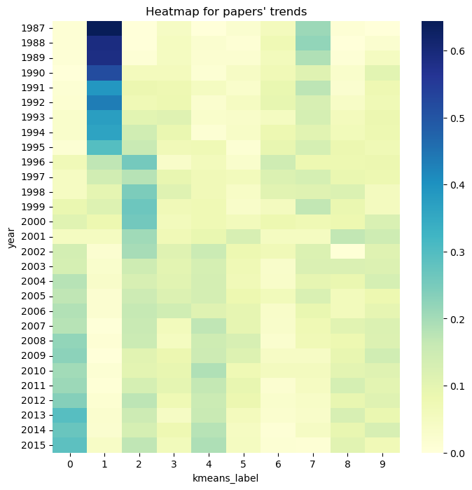

```python
import seaborn as sns

plt.figure(figsize=(8,8))
sns.heatmap(pivot_scaled, cmap="YlGnBu")
plt.title("Heatmap for papers' trends")
plt.show()
```

K means topics

- topic 1 -> LDA topic 6: matrix computation & convex optimization
- topic 2 -> LDA topic 10: neural network
- topic 3 -> LDA topic 5: probalilistic model & statistical machine learning
- topic 4 -> LDA topic 7: computer visual & image segmentation
- topic 5 -> LDA topic 1: graph theory
- topic 6 -> LDA topic 8: probalilistic model & prediction model
- topic 7 -> LDA topic 2: biology application
- topic 8 -> LDA topic 9: neuron science
- topic 9 -> LDA topic 4: reinforcement learning
- topic 10 -> LDA topic 3: classification and clustering

# PCA

```python
from sklearn.decomposition import PCA

pca = PCA(n_components=9, svd_solver="arpack")
pca.fit(topics_df)
```

```
PCA(n_components=9, svd_solver='arpack')
```

```python
print(pca.explained_variance_ratio_)
```

```
[0.22391212 0.15741659 0.13676365 0.11995365 0.10502999 0.09123297
 0.0687732  0.05172167 0.04519615]
```

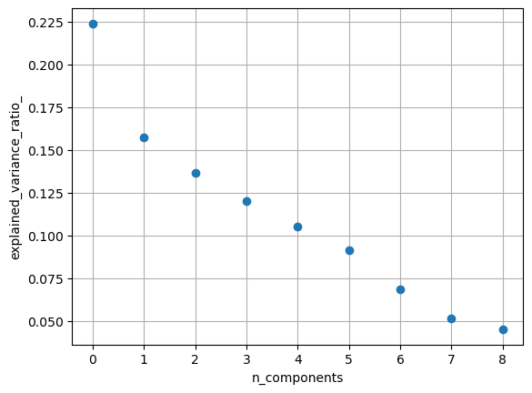

```python
plt.plot(pca.explained_variance_ratio_, "o", linewidth=2)
plt.axis('tight')
plt.xlabel('n_components')
plt.ylabel('explained_variance_ratio_')
plt.grid()
plt.show()
```

```python
Y = pca.components_;
Y.shape
```

```
(9, 10)
```

# MDS

```python
from sklearn.manifold import MDS
```

```python
embedding = MDS(n_components=2)
X_transformed = embedding.fit_transform(topics_df)
X_transformed.shape
```

```
(5811, 2)
```

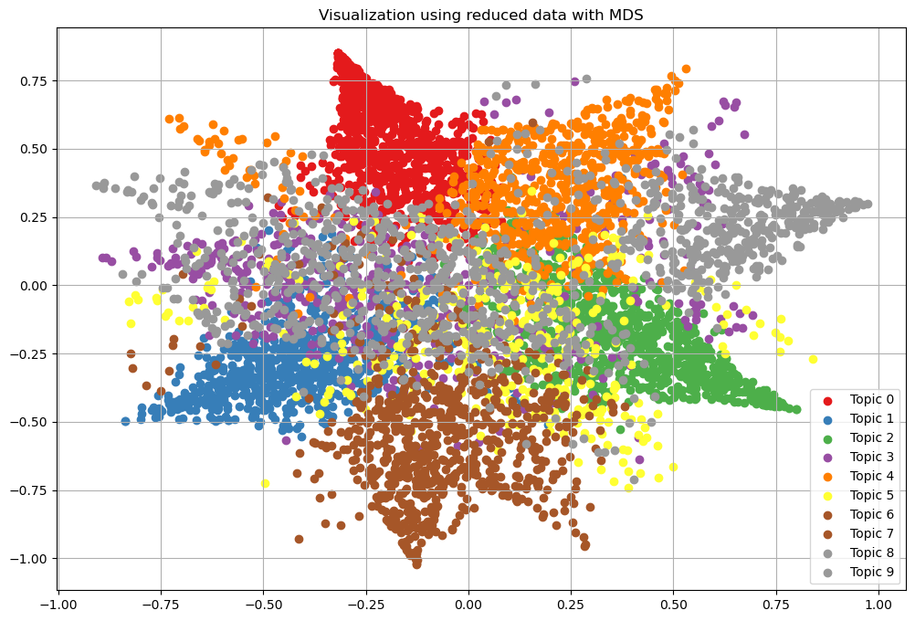

```python
from matplotlib import cm

k_for_kmeans = 10
plt.figure(figsize=(12,8))

colors = cm.get_cmap("Set1", k_for_kmeans)

for i in range(k_for_kmeans):
    plt.scatter(X_transformed[papers_label_l==i, 0], X_transformed[papers_label_l==i, 1],
                label="Topic {}".format(i),
               c=[colors(i)])
plt.title("Visualization using reduced data with MDS")
plt.grid()
plt.legend()
plt.show()
```

# manifold

```python
from sklearn import manifold
```

```python
n_neighbors = 18  # neighborhood which is used to recover the locally linear structure
n_components = 2  # number of coordinates for the manifold

params = {
    "n_neighbors": n_neighbors,
    "n_components": n_components,
    "eigen_solver": "dense",
    "random_state": 0,
}

lle_standard = manifold.LocallyLinearEmbedding(method="standard", **params)
X_standard = lle_standard.fit_transform(topics_df)

#lle_ltsa = manifold.LocallyLinearEmbedding(method="ltsa", **params)
#X_ltsa = lle_ltsa.fit_transform(topics_df)

#lle_hessian = manifold.LocallyLinearEmbedding(method="hessian", **params)
#X_hessian = lle_hessian.fit_transform(topics_df)

lle_mod = manifold.LocallyLinearEmbedding(method="modified", **params)
X_mod = lle_mod.fit_transform(topics_df)
```

```python
t_sne = manifold.TSNE(
    n_components=n_components,
    perplexity=50,
    early_exaggeration=24,
    init="random",
    n_iter=250,
    random_state=0,
)

X_t_sne = t_sne.fit_transform(topics_df)
```

```python
isomap = manifold.Isomap(n_neighbors=n_neighbors, n_components=n_components, p=2)
X_isomap = isomap.fit_transform(topics_df)
```

```python
X_standard.shape
```

```
(5811, 2)
```

```python
X_mod.shape
```

```
(5811, 2)
```

```python
X_t_sne.shape
```

```
(5811, 2)
```

```python
X_isomap.shape
```

```
(5811, 2)
```

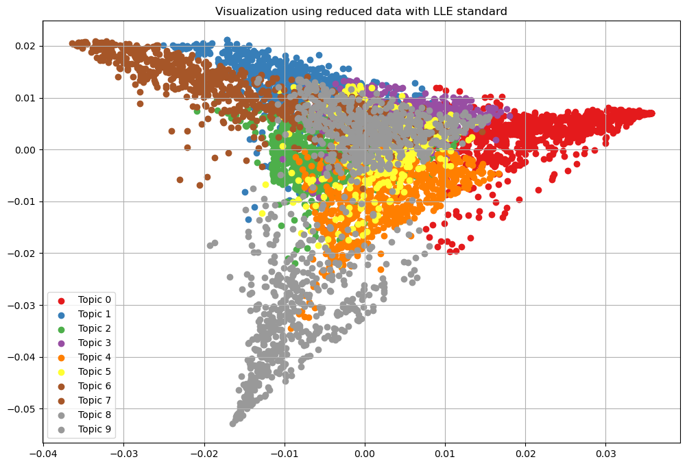

```python
plt.figure(figsize=(12,8))

colors = cm.get_cmap("Set1", k_for_kmeans)

for i in range(k_for_kmeans):
    plt.scatter(X_standard[papers_label_l==i, 0], X_standard[papers_label_l==i, 1],
                label="Topic {}".format(i),
               c=[colors(i)])
plt.title("Visualization using reduced data with LLE standard")
plt.grid()
plt.legend()
plt.show()
```

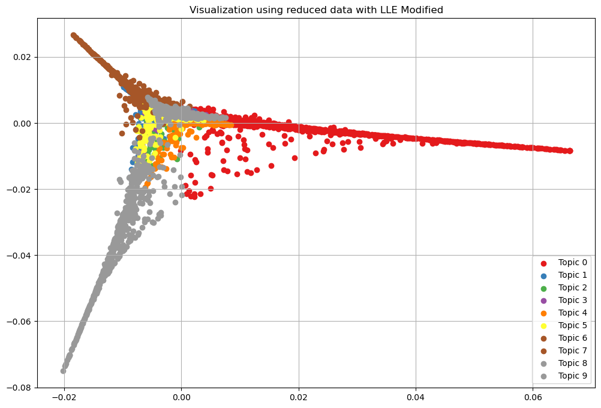

```python
plt.figure(figsize=(12,8))

colors = cm.get_cmap("Set1", k_for_kmeans)

for i in range(k_for_kmeans):
    plt.scatter(X_mod[papers_label_l==i, 0], X_mod[papers_label_l==i, 1],
                label="Topic {}".format(i),
               c=[colors(i)])
plt.title("Visualization using reduced data with LLE Modified")
plt.grid()
plt.legend()
plt.show()
```

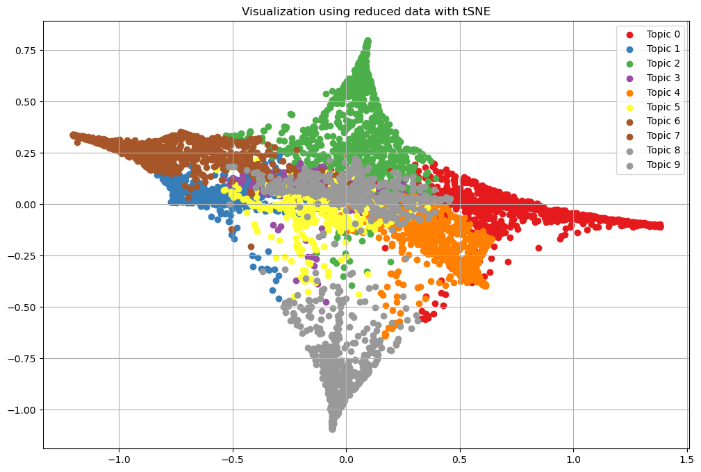

```python
plt.figure(figsize=(12,8))

colors = cm.get_cmap("Set1", k_for_kmeans)

for i in range(k_for_kmeans):
    plt.scatter(X_t_sne[papers_label_l==i, 0], X_t_sne[papers_label_l==i, 1],
                label="Topic {}".format(i),
               c=[colors(i)])
plt.title("Visualization using reduced data with tSNE")
plt.grid()
plt.legend()
plt.show()
```

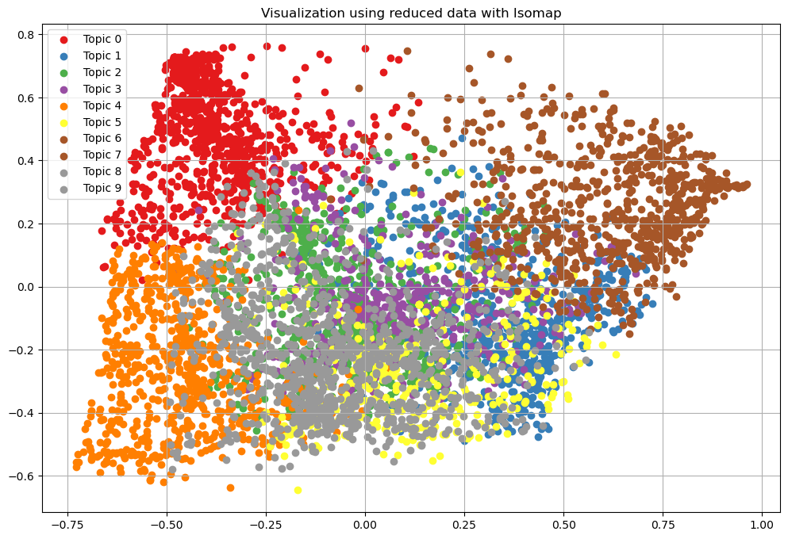

```python
plt.figure(figsize=(12,8))

colors = cm.get_cmap("Set1", k_for_kmeans)

for i in range(k_for_kmeans):
    plt.scatter(X_isomap[papers_label_l==i, 0], X_isomap[papers_label_l==i, 1],
                label="Topic {}".format(i),
               c=[colors(i)])
plt.title("Visualization using reduced data with Isomap")
plt.grid()
plt.legend()
plt.show()
```